# HW.Explore.3

Logan Hardy

1/13/2022

30 points (25 for this assignment, 5 for being on time)

# Import the data (2 points)

Import the mental health survey data using the third method we used in the in class file (readr with character to factor conversion)

```r
mental_health_tech_survey <- read_csv("../Data/mental_health_tech_survey.csv") %>% mutate_if(is.character, as.factor)
```

## Factor Functions (6 points)

Using the gender variable, please complete the following:

1. Print out all the categories in alphabetical order.
2. Print out how many levels there are.
3. Print out a table of all of the categories and their frequencies.
4. Print out the number of missing values in this column.

```r
sort(unique(mental_health_tech_survey$Gender))
```

```
##  [1] A little about you
##  [2] Agender
##  [3] All
##  [4] Androgyne
##  [5] cis-female/femme
##  [6] Cis Female
##  [7] cis male
##  [8] Cis Male
##  [9] Cis Man
## [10] Enby
## [11] f
## [12] F
## [13] femail
## [14] Femake
## [15] female
```

[output cut: 33 more lines]

```r
length(unique(mental_health_tech_survey$Gender))
```

```
## [1] 47
```

```r
fct_count(mental_health_tech_survey$Gender, sort = TRUE)
```

```
## # A tibble: 47 x 2
##    f          n
##    <fct>  <int>
##  1 Male     618
##  2 male     206
##  3 Female   123
##  4 M        116
##  5 female    62
##  6 F         38
##  7 m         34
##  8 f         15
##  9 Make       4
## 10 Woman      3
## # ... with 37 more rows
```

```r
is.na(mental_health_tech_survey$Gender)
```

[output not shown]

[output cut: 90 more lines]

Q: Based on what you see here, is this factor column clean? (Meaning there are no duplicate groups or typos.) If not, what are some things you would change? A: No, combine duplicate groups/typos together (M, m, Male, male, Mail, Mal all as Male)

Q: Please list five levels found in this factor variable that could be combined into a single level A: M, m, Male, male, Mail, Mal all as Male

## Numeric Functions (8 points)

Note, you can perform many numeric functions on POSIXct variables. Check to make sure that your Timestamp variable is in the POSIXct format. If it is not, make sure you imported your dataset using read_csv() instead of read.csv(). If you still can’t get it into a POSIXct format please contact me or a TA.

For the Timestamp variable, use all of our numeric functions on it.

1. Find the median
2. Find the minimum and maximum
3. Find the kurtosis and skew
4. Find the quantiles

```r
#str(mental_health_tech_survey)
median(mental_health_tech_survey$Timestamp, na.rm = TRUE)
```

```
## [1] "2014-08-28 02:30:00 UTC"
```

```r
min(mental_health_tech_survey$Timestamp, na.rm = TRUE)
```

```
## [1] "2014-08-27 11:29:31 UTC"
```

```r
max(mental_health_tech_survey$Timestamp, na.rm = TRUE)
```

```
## [1] "2016-02-01 23:04:31 UTC"
```

```r
kurtosis(mental_health_tech_survey$Timestamp, na.rm = TRUE)
```

```
## [1] 30.47364
```

```r
skewness(mental_health_tech_survey$Timestamp, na.rm = TRUE)
```

```
## [1] 4.932289
```

```r
quantile(mental_health_tech_survey$Timestamp, na.rm = TRUE)
```

```
##                        0%                       25%                       50%
## "2014-08-27 11:29:31 UTC" "2014-08-27 14:26:56 UTC" "2014-08-28 02:30:00 UTC"
##                       75%                      100%
## "2014-08-28 23:36:48 UTC" "2016-02-01 23:04:31 UTC"
```

Q: Based on this output, which of these functions work for date time variables? A: All of these functions work for date time

Q: Is this variable positively skewed, or negatively skewed? A: positively skewed

## Logical Functions (3 points)

We don’t have any logical columns in this dataset, so we get to make one for this example by revaluing a factor variable with two categories. Simply run the code below.

```r
mental_health_tech_survey <- mental_health_tech_survey %>% mutate(obs_consequence = ifelse(obs_consequence == "Yes", TRUE, FALSE))
```

For the obs_consequence column:

1. Print out the proportion of values that are true.
2. Print out the number of values that are true.

```r
mean(mental_health_tech_survey$obs_consequence, na.rm = TRUE)
```

```
## [1] 0.1461477
```

```r
sum(mental_health_tech_survey$obs_consequence, na.rm = TRUE)
```

```
## [1] 184
```

Q: What percentage of respondents put “Yes” (now TRUE) on this question? Round to one decimal place. A: 14.6%

## Descriptive table (3 points)

Use a code snippet or the in class file to pull in the descriptive table function. Then run this mental health survey through it.

```r
descr_table <- function(df) {

  df_num <- select_if(df, function(col) is.numeric(col) | is.logical(col)  | is.Date(col))
  df_fac <- select(df, setdiff(colnames(df), colnames(df_num)))
  none <- rep("None", ncol(df_fac))

  matrix <- matrix(nrow = ncol(df), ncol=11, dimnames = list(c(names(df_num), names(df_fac)), c("Mean","Max","Min", "Std Dev", "Median", "Kurt", "Skew", "# Missing", "# Unique", "Class", "Mode")))

  matrix[,1] <- c(sapply(df_num, function(x) round(mean(x, na.rm = TRUE), 2)), none)
  matrix[,2] <- c(sapply(df_num, function(x) max(x, na.rm = TRUE)), none)
  matrix[,3] <- c(sapply(df_num, function(x) min(x, na.rm = TRUE)), none)
  matrix[,4] <- c(sapply(df_num, function(x) round(sd(x, na.rm = TRUE), 2)), none)
  matrix[,5] <- c(sapply(df_num, function(x) median(x, na.rm = TRUE)), none)
  matrix[,6] <- c(sapply(df_num, function(x) round(moments::kurtosis(x, na.rm = TRUE), 2)), none)
  matrix[,7] <- c(sapply(df_num, function(x) round(moments::skewness(x, na.rm = TRUE), 2)), none)
  matrix[,8] <- sapply(cbind(df_num, df_fac), function(x) sum(is.na(x)))
  matrix[,9] <- as.character(sapply(cbind(df_num, df_fac), function(x) length(unique(x))))
  matrix[,10] <- as.character(sapply(cbind(df_num, df_fac), function(x) class(x)))
  matrix[,11] <- sapply(cbind(df_num, df_fac), function(x) names(sort(table(x),decreasing=TRUE)[1]))
  matrix <- as.data.frame(matrix)
  return(matrix)
}

descr_table(mental_health_tech_survey)
```

```
##                                  Mean         Max   Min       Std Dev Median
## Age                       79428148.31 99999999999 -1726 2818299442.98     31
## obs_consequence                  0.15           1     0          0.35      0
## Timestamp                        None        None  None          None   None
## Gender                           None        None  None          None   None
## Country                          None        None  None          None   None
## state                            None        None  None          None   None
## self_employed                    None        None  None          None   None
## family_history                   None        None  None          None   None
## treatment                        None        None  None          None   None
## work_interfere                   None        None  None          None   None
## no_employees                     None        None  None          None   None
## remote_work                      None        None  None          None   None
## tech_company                     None        None  None          None   None
## benefits                         None        None  None          None   None
## care_options                     None        None  None          None   None
## wellness_program                 None        None  None          None   None
## seek_help                        None        None  None          None   None
## anonymity                        None        None  None          None   None
## leave                            None        None  None          None   None
## mental_health_consequence        None        None  None          None   None
## phys_health_consequence          None        None  None          None   None
## coworkers                        None        None  None          None   None
## supervisor                       None        None  None          None   None
## mental_health_interview          None        None  None          None   None
## phys_health_interview            None        None  None          None   None
## mental_vs_physical               None        None  None          None   None
## comments                         None        None  None          None   None
##                           Kurt  Skew # Missing # Unique                  Class
## Age                       1257 35.44         0       53                numeric
## obs_consequence           5.01     2         0        2                logical
## Timestamp                 None  None         0     1246 c("POSIXct", "POSIXt")
## Gender                    None  None         0       47                 factor
## Country                   None  None         0       48                 factor
## state                     None  None       515       46                 factor
## self_employed             None  None        18        3                 factor
## family_history            None  None         0        2                 factor
## treatment                 None  None         0        2                 factor
## work_interfere            None  None       264        5                 factor
## no_employees              None  None         0        6                 factor
```

[output cut: 29 more lines]

```
## tech_company                                          Yes
## benefits                                              Yes
## care_options                                           No
## wellness_program                                       No
## seek_help                                              No
## anonymity                                      Don't know
## leave                                          Don't know
## mental_health_consequence                              No
## phys_health_consequence                                No
## coworkers                                    Some of them
## supervisor                                            Yes
## mental_health_interview                                No
## phys_health_interview                               Maybe
## mental_vs_physical                             Don't know
## comments                  * Small family business - YMMV.
```

Q: Based on the resulting table, what is the most common age of respondents in this dataset? A: 29

Q: Which variable has the most unique values? A: Timestamp

## Visualization (3 points)

Copy and paste theme_new from the visualization html. Make a histogram of the timestamp variable.

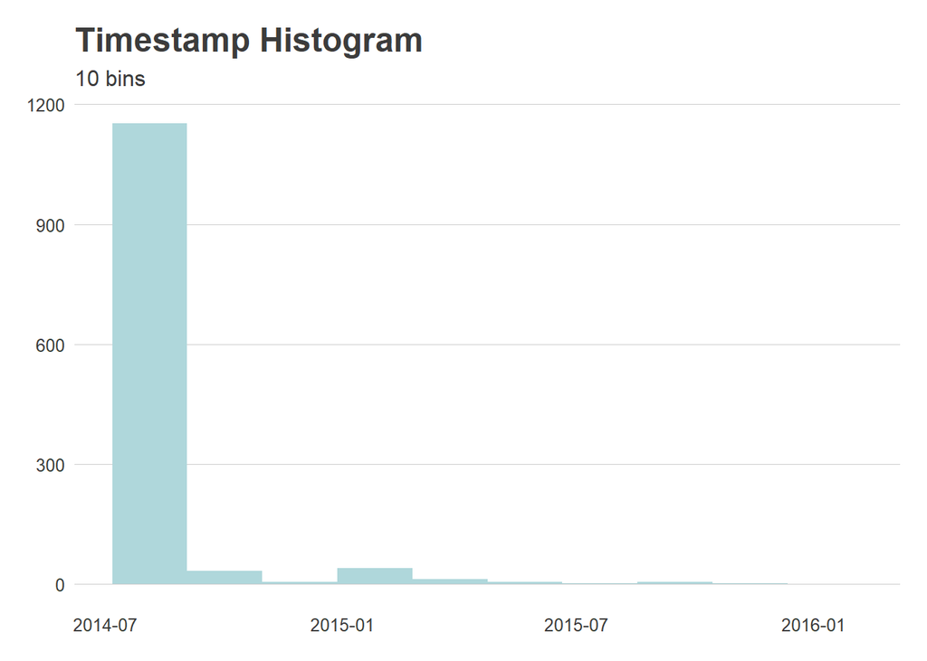

```r
theme_new <-  theme_fivethirtyeight(base_size=12#,base_family="Open Sans"
                                    ) %+replace% theme(panel.grid.major.y = element_line(colour = "grey80", size = 0.25),  panel.grid.major.x = element_blank(), panel.background = element_rect(fill = "white"), plot.background = element_rect(fill = "white"), legend.background = element_rect(fill = "white"))

#hist(mental_health_tech_survey$Timestamp, breaks = 10)
mental_health_tech_survey %>%
        ggplot(aes(x = Timestamp)) + geom_histogram(fill = "#afd7db", bins=10) +
        labs(title = "Timestamp Histogram",
            subtitle = "10 bins",
            y = "Count",
            x = "Variable") +
        theme_new #+ theme(axis.title = element_text(size = 10, color = "grey40"))
```

Q: Did most people take the survey at a similar time to other people, or spread out? A: Similar time

Make a bar chart of the no_employees column

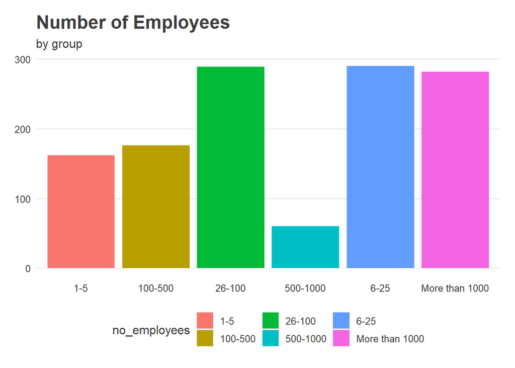

```r
mental_health_tech_survey %>%
        ggplot(aes(x = no_employees, fill = no_employees)) +
        geom_bar() +
        labs(title = "Number of Employees",
            subtitle = "by group") +
        theme_new
```

Q: Ideally, an ordinal variable than this should have all the factors in the correct order. Is this one in the right order? A: No, it is not.

# Optional feedback:

How hard was this assignment? Was it: too hard, too easy, or just right?

ANSWER: Just right

Approximately how long did this assignment take you?

ANSWER: 1.5 hours